# Self-Driving Car Engineer Nanodegree

## Project: Build a Traffic Sign Recognition Classifier

In this notebook, a template is provided for you to implement your functionality in stages, which is required to successfully complete this project. If additional code is required that cannot be included in the notebook, be sure that the Python code is successfully imported and included in your submission if necessary.

In addition to implementing code, there is a writeup to complete. The writeup should be completed in a separate file, which can be either a markdown file or a pdf document. There is a [write up template](https://github.com/udacity/CarND-Traffic-Sign-Classifier-Project/blob/master/writeup_template.md) that can be used to guide the writing process. Completing the code template and writeup template will cover all of the [rubric points](https://review.udacity.com/#!/rubrics/481/view) for this project.

The [rubric](https://review.udacity.com/#!/rubrics/481/view) contains "Stand Out Suggestions" for enhancing the project beyond the minimum requirements. The stand out suggestions are optional. If you decide to pursue the "stand out suggestions", you can include the code in this Ipython notebook and also discuss the results in the writeup file.

> **Note:** Code and Markdown cells can be executed using the **Shift + Enter** keyboard shortcut. In addition, Markdown cells can be edited by typically double-clicking the cell to enter edit mode.

## Code Structure

In this notebook, I have tried to follow a pattern in which, within each code cell, I implement a function for a task, and towards the end of the cell, I have a 'test' function which invokes that function right away, so that we are testing the functionality as we are building it out. This reduces surprises, when we start using the functions later on to do more complex tasks.

## Common Constants

```python
# Useful to have these defined up front for clear visibility

const_desired_accuracy_for_validation_data = 0.939 # A bit more than the project requiremenets of 93%
const_minimum_validation_accuracy_to_save_to_disk = 0.90 # Start saving model(s) to disk once we reach this threshold, early on in the training process this threshold can be low, and as we train further, we can increase this.
const_model_name_to_save = './jltrafficclassifier' # probably a better name would be germantrafficclassifier
const_new_images_folder = "NewImages/" # Folder where new images sourced from the internet are located
const_top_k_softmax = 5 # For new image categorization, this constant defines the top 'X' predicted classes
const_for_pixel_normalization = 128.0 # Constant for image pixel intensity normalization ( because pixel intensity range is 0, 255 )
const_get_top_x_misclassified_classes = 4 # Once a trained model is used to make predictions, this constant is used to determine how many misclassified classes to we want to investigate
```

## Common Imports

```python
# Including common imports for the notebook
# There might be a slight performance penalty in including these all up front rather than including them as needed, but it definitely improves the readability

import numpy as np
import os # Used for inspecting the folder structure, and loading or writing files to disk
import sys
import time # Used for calculating the run-time of code segments
import scipy
import json
import matplotlib.pyplot as plt
# this signifies that we will use matplotlib to show graphics inline within the jupyter notebook
%matplotlib inline
import matplotlib.image as mpimg
import cv2
import tensorflow as tf
import copy # Used to make copy of images for processing, rather than operating on the original images
import resource # Useful for getting memory usage
from random import randint
import operator
```

## Define Convenience Logging Functions

```python
# Useful to selectively turn on / off logging at different levels

const_info_log_enabled = True
def infoLog(logMessage):
    if const_info_log_enabled == True:
        print("")
        print(logMessage)

const_debug_log_enabled = True
def debugLog(logMessage):
    if const_debug_log_enabled == True:
        print("")
        print(logMessage)

const_warning_log_enabled = True
def warningLog(logMessage):
    if const_warning_log_enabled == True:
        print("")
        print(logMessage)

const_error_log_enabled = True
def errorLog(logMessage):
    if const_error_log_enabled == True:
        print("")
        print(logMessage)
```

### Convenience Function to print memory usage

```python
# Early on in the training process, I ran into issues where I was getting a memory error
# This was resolved by terminating the Docker process, terminating all notebooks, restarting Chrome, relaunching Docker, and relaunching the notebooks
# Jupyter notebooks tend to become 'heavy' when there size increases, so the restarts were a regular feature ( once everyday ) of the overall process

def print_memory_usage():
    infoLog("{} Kb".format(resource.getrusage(resource.RUSAGE_SELF).ru_maxrss))

print_memory_usage()
```

```
127964 Kb
```

### Convenience Mapper to convert a classId to Sign Name

```python
## Provides an easy way to convert the class ID to a human interpretable format
## Allows us to avoid having to do a manual lookup of signnames.csv each time.
## A better approach would be to read the CSV file, and to not have this hard coded here, but this is sufficient for us

classIdSignNameDict = {0:"Speed limit (20km/h)",
1:"Speed limit (30km/h)",
2:"Speed limit (50km/h)",
3:"Speed limit (60km/h)",
4:"Speed limit (70km/h)",
5:"Speed limit (80km/h)",
6:"End of speed limit (80km/h)",
7:"Speed limit (100km/h)",
8:"Speed limit (120km/h)",
9:"No passing",
10:"No passing for vehicles over 3.5 metric tons",
11:"Right-of-way at the next intersection",
12:"Priority road",
13:"Yield",
14:"Stop",
15:"No vehicles",
16:"Vehicles over 3.5 metric tons prohibited",
17:"No entry",
18:"General caution",
19:"Dangerous curve to the left",
20:"Dangerous curve to the right",
21:"Double curve",
22:"Bumpy road",
23:"Slippery road",
24:"Road narrows on the right",
25:"Road work",
26:"Traffic signals",
27:"Pedestrians",
28:"Children crossing",
29:"Bicycles crossing",
30:"Beware of ice/snow",
31:"Wild animals crossing",
32:"End of all speed and passing limits",
33:"Turn right ahead",
34:"Turn left ahead",
35:"Ahead only",
36:"Go straight or right",
37:"Go straight or left",
38:"Keep right",
39:"Keep left",
40:"Roundabout mandatory",
41:"End of no passing",
42:"End of no passing by vehicles over 3.5 metric tons"}

def getSignNameForClassId(classId):
    return classIdSignNameDict[classId]

infoLog(getSignNameForClassId(0))
```

```
Speed limit (20km/h)
```

## Define Convenience Function to rotate an image by an arbitrary angle

```python
# This can be used to rotate an image to manufacture fake data

from scipy.ndimage import rotate

def rotateImage(image):
    randomRotationAngle = np.random.randint(0, 360)
    rotated_image = rotate(image, randomRotationAngle, reshape=False)
    return rotated_image
```

## Define Convenience Function to visualize samples of an image data array

```python
# Given an array of images, this function plots 10 random images from this array
# Also does a lookup on the class ID to provide a convenient title for the image, for quick validation

def visualizeSamplesFromData(image_data_array, labels_array):
    for counter in range(0, 10):
        image_index = np.random.randint(0, len(image_data_array))
        image = image_data_array[image_index]
        labelId = labels_array[image_index]
        labelIdName = getSignNameForClassId(labelId)
        squeezedImage = image.squeeze()
        plt.figure(figsize=(3,3))
        plt.title(labelIdName)
        plt.imshow(squeezedImage)
```

## Define Convenience Function to store data as JSON file for later analysis

```python
# At the end of the training and validation process after all epochs have executed, we write the overall performance, run time, accuracy trends to a JSON file on the Disk under the folder data_for_analysis
# I chose JSON because this is human readable / consumable easily.
# The name of the file is the current epoch time - e.g. '1492470140.0814645', which you can view with a text editor

import json

const_data_analysis_folder = 'data_for_analysis'

def saveDataToDiskAsJson(data):
    if not os.path.exists(const_data_analysis_folder):
        os.makedirs(const_data_analysis_folder)
    currentTime = time.time()
    filename = const_data_analysis_folder + '/' + str(currentTime)
    try:
        with open(filename, 'w') as outfile:
            json.dump(data, outfile)
            debugLog("Performance Data Stored as JSON file to: " + filename)
    except IndexError:
        warningLog("Caught IndexError in saveDataToDiskAsJson.")

def getDataFromDisk(filename):
    filename = const_data_analysis_folder + '/' + filename
    with open(filename) as infile:
        data = json.load(infile)
```

## Define Convenience Function to store data as pickle file for later analysis

```python
# Sample to write Data as Pickle File and read it back
# Pickle file(s) are used in the project to save and restore Normalized training data, under the folder 'pickle_data_for_analysis'
# As part of the validation process, we write and read back a file named apple.pickle to the folder

import pickle

data_to_test_pickle = {1,2,3,4,5}

const_pickle_data_analysis_folder = 'pickle_data_for_analysis'

def saveDataToDiskAsPickle(data, param_filename = None):
    if not os.path.exists(const_pickle_data_analysis_folder):
        os.makedirs(const_pickle_data_analysis_folder)

    fileName = param_filename

    if not fileName:
        filename = str(time.time())

    filename = const_pickle_data_analysis_folder + '/' + param_filename + '.pickle'

    debugLog("Data writing started : " + filename)

    with open(filename, 'wb') as handle:
        pickle.dump(data, handle, pickle.HIGHEST_PROTOCOL)

    debugLog("Data writing complete : " + filename)


def getDataFromPickleFile(filename):
    returnData = None
    filename = const_pickle_data_analysis_folder + '/' + filename + '.pickle'
    try:
        with open(filename, 'rb') as handle:
            returnData = pickle.load(handle)
            infoLog("Found data for " + filename)
        return returnData
    except FileNotFoundError:
        return None

saveDataToDiskAsPickle(data_to_test_pickle, 'apple')
debugLog(getDataFromPickleFile("apple"))
```

```
Data writing started : pickle_data_for_analysis/apple.pickle

Data writing complete : pickle_data_for_analysis/apple.pickle

Found data for pickle_data_for_analysis/apple.pickle

{1, 2, 3, 4, 5}
```

## Define Convenience Function to make sound

```python
# This can be used to indicate the completion of training for example
# This works on a Mac, but not sure of other platforms

def makeSound():
    os.system("printf '\a'") # or '\7'
```

## Define Convenience method to show progress indicator of a process

```python
# Shows a nice progress bar for long running operations
# Used From - http://stackoverflow.com/questions/3173320/text-progress-bar-in-the-console

def progressIndicator(count, total, suffix=''):
    bar_len = 60
    filled_len = int(round(bar_len * count / float(total)))

    percents = round(100.0 * count / float(total), 1)
    bar = '=' * filled_len + '-' * (bar_len - filled_len)

    sys.stdout.write('[%s] %s%s ...%s\r' % (bar, percents, '%', suffix))
    sys.stdout.flush()
```

## Step 0: Load The Data

### Load the validation and testing data

```python
# Load pickled data as downloaded from https://d17h27t6h515a5.cloudfront.net/topher/2017/February/5898cd6f_traffic-signs-data/traffic-signs-data.zip
# We load the validation and testing data initially, while the training data is loaded later

import pickle
import numpy

# TODO: Fill this in based on where you saved the training and testing data

validation_file = 'traffic-signs-data/valid.p'
testing_file = 'traffic-signs-data/test.p'

with open(validation_file, mode='rb') as f:
    valid = pickle.load(f)
with open(testing_file, mode='rb') as f:
    test = pickle.load(f)

X_valid, y_valid = valid['features'], valid['labels']
X_test, y_test = test['features'], test['labels']

# JL - explore the data keys
infoLog("Validation Data Keys : " + str(valid.keys()))
infoLog("Test Data Keys : " + str(test.keys()))

# JL - explore data shape
X_valid_shape = X_valid.shape
y_valid_shape = y_valid.shape
X_test_shape = X_test.shape
y_test_shape = y_test.shape

infoLog("Shape of X_valid : " + str(X_valid_shape))
infoLog("Shape of y_valid : " + str(y_valid_shape))
infoLog("Shape of X_test : " + str(X_test_shape))
infoLog("Shape of y_test : " + str(y_test_shape))
```

```
Validation Data Keys : dict_keys(['coords', 'labels', 'sizes', 'features'])

Test Data Keys : dict_keys(['coords', 'features', 'sizes', 'labels'])

Shape of X_valid : (4410, 32, 32, 3)

Shape of y_valid : (4410,)

Shape of X_test : (12630, 32, 32, 3)

Shape of y_test : (12630,)
```

### Include an exploratory visualization of the validation dataset

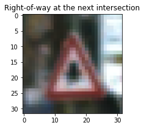

[figure not shown]

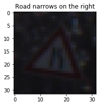

[figure not shown]

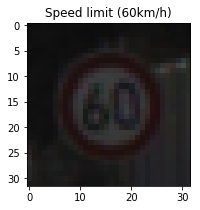

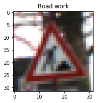

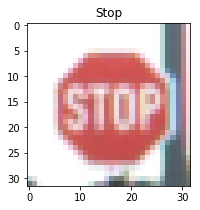

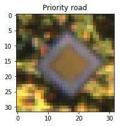

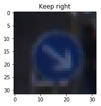

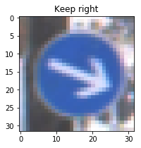

```python
visualizeSamplesFromData(X_valid,y_valid)
```

### Include an exploratory visualization of the testing dataset

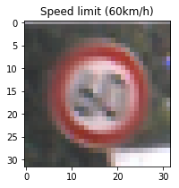

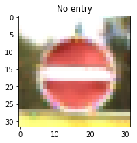

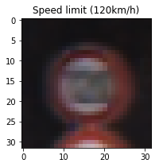

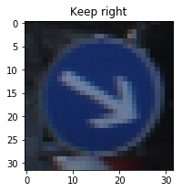

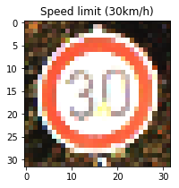

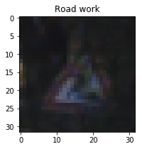

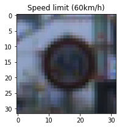

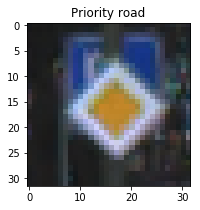

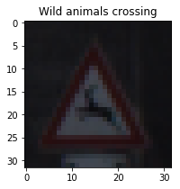

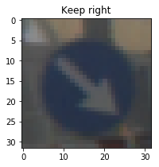

```python
visualizeSamplesFromData(X_test,y_test)
```

### Load training data from Disk ( normalized or non-normalized )

```python
# This section is used to load the normalized training data, if stored already on the Disk
# If training data has not been normalized, we load the 'default' data as provided in the original set, and normalize and save it later

import pickle
import numpy

# Load training data
training_file = 'traffic-signs-data/train.p'
with open(training_file, mode='rb') as f:
    train = pickle.load(f)

X_train, y_train = train['features'], train['labels']

infoLog("Training Data Keys : " + str(train.keys()))

# Check if we already have normalized data saved to disk
X_train_normalized = getDataFromPickleFile('X_train_normalized')
y_train_normalized = getDataFromPickleFile('y_train_normalized')

is_training_data_normalized = False

if X_train_normalized is not None:
    infoLog("Normalized training data loaded from Disk.")
    is_training_data_normalized = True
    X_train = X_train_normalized
    y_train = y_train_normalized
else:
    infoLog("Training data has not been previously normalized.")
    is_training_data_normalized = False
```

```
Training Data Keys : dict_keys(['coords', 'labels', 'sizes', 'features'])

Found data for pickle_data_for_analysis/X_train_normalized.pickle

Found data for pickle_data_for_analysis/y_train_normalized.pickle

Normalized training data loaded from Disk.
```

### Explore shape of training data

```python
# Explore shape of the training data

X_train_shape = X_train.shape
y_train_shape = y_train.shape

infoLog("Shape of X_train : " + str(X_train_shape))
infoLog("Shape of y_train : " + str(y_train_shape))
```

```
Shape of X_train : (34799, 32, 32, 3)

Shape of y_train : (34799,)
```

### Explore unique data labels by viewing labels from training, validation and test data

```python
# Explore unique data labels

combined_labels_array = numpy.concatenate((y_train,y_valid,y_test))
num_of_unique_labels_in_all_data = len(numpy.unique(combined_labels_array))
infoLog("Total Number of Unique Labels: " + str(num_of_unique_labels_in_all_data))
```

```
Total Number of Unique Labels: 43
```

### Explore shape of one training image

```python
# Explore shape of one training image, so that we know the shape of the input to our neural network

X_train_zero_shape = X_train[0].shape
infoLog("Shape of X_train[0] : " + str(X_train_zero_shape))
```

```
Shape of X_train[0] : (32, 32, 3)
```

### Include an exploratory visualization of the training dataset

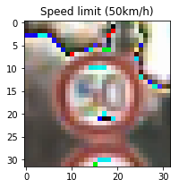

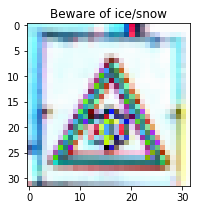

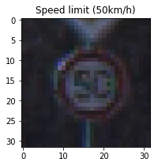

[figure not shown]

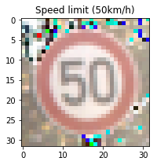

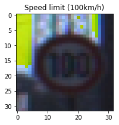

[figure not shown]

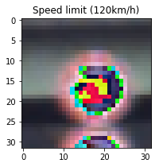

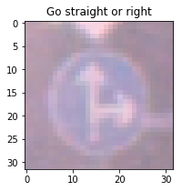

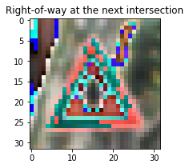

```python
# Visualize the loaded training data ( normalized or non-normalized )

visualizeSamplesFromData(X_train, y_train)
```

## Step 1: Dataset Summary & Exploration

The pickled data is a dictionary with 4 key/value pairs:

- `'features'` is a 4D array containing raw pixel data of the traffic sign images, (num examples, width, height, channels).
- `'labels'` is a 1D array containing the label/class id of the traffic sign. The file `signnames.csv` contains id -> name mappings for each id.
- `'sizes'` is a list containing tuples, (width, height) representing the original width and height the image.
- `'coords'` is a list containing tuples, (x1, y1, x2, y2) representing coordinates of a bounding box around the sign in the image. **THESE COORDINATES ASSUME THE ORIGINAL IMAGE. THE PICKLED DATA CONTAINS RESIZED VERSIONS (32 by 32) OF THESE IMAGES**

Complete the basic data summary below. Use python, numpy and/or pandas methods to calculate the data summary rather than hard coding the results. For example, the [pandas shape method](http://pandas.pydata.org/pandas-docs/stable/generated/pandas.DataFrame.shape.html) might be useful for calculating some of the summary results.

### Provide a Basic Summary of the Data Set Using Python, Numpy and/or Pandas

```python
# Additional data points regarding training, validation and test data

# Number of training examples
n_train = X_train_shape[0]

# Number of validation examples
n_validation = X_valid_shape[0]

# Number of testing examples.
n_test = X_test_shape[0]

# What's the shape of an traffic sign image?
image_shape = (X_test_shape[1],X_test_shape[2])

# How many unique classes/labels there are in the dataset.
n_classes = num_of_unique_labels_in_all_data

infoLog("Number of training examples = " + str(n_train))
infoLog("Number of validation examples = " + str(n_validation))
infoLog("Number of testing examples = " + str(n_test))
infoLog("Image data shape = " + str(image_shape))
infoLog("Number of classes = " + str(n_classes))
```

```
Number of training examples = 34799

Number of validation examples = 4410

Number of testing examples = 12630

Image data shape = (32, 32)

Number of classes = 43
```

### Explore distribution of number of training labels for various classes

Our goal here is to determine which classes are more heavily represented in the training data, and to then increased the representation for under represented classes so that the model gets proper training on all types of classifier(s)

[output not shown]

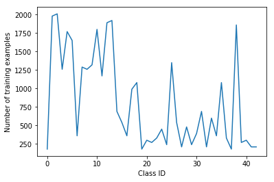

```python
# Generate and visualize statistics regarding distribution of Class Labels and Instances for training data
# This is useful to determine which classes are highly represented, and which classes are less represented
# By intuition, the neural network will learn those classes better, for whom we have more training data, and will learn those classes poorly, for whom we have less training data

import numpy as np
import matplotlib.pyplot as plt

def generate_class_distribution(classArray):
    classIds, countsForClassIds = np.unique(y_train, return_counts=True)
    labels_count_dictionary = dict(zip(classIds, countsForClassIds))
    mean_number_of_samples_per_class_list_training_data = int(np.mean(countsForClassIds))
    standard_deviation_number_of_samples_per_class_list_training_data = np.std(countsForClassIds)
    max_number_of_samples_per_class_list_training_data = int(np.max(countsForClassIds))

    debugLog("function: generate_class_distribution")
    debugLog("Labels Dictionary : " + str(labels_count_dictionary))
    debugLog("Mean num classes per label: " + str(mean_number_of_samples_per_class_list_training_data))
    debugLog("Standard Deviation of num classes per label: " + str(standard_deviation_number_of_samples_per_class_list_training_data))
    debugLog("Max num classes per label : " + str(max_number_of_samples_per_class_list_training_data))

    return labels_count_dictionary, mean_number_of_samples_per_class_list_training_data,standard_deviation_number_of_samples_per_class_list_training_data,max_number_of_samples_per_class_list_training_data

def visualize_class_distribution(labels_count_dictionary):

    classIdlist_training_data = list(labels_count_dictionary.keys())
    number_of_samples_per_class_list_training_data = list(labels_count_dictionary.values())
    plt.plot(classIdlist_training_data,number_of_samples_per_class_list_training_data)
    plt.ylabel('Number of training examples')
    plt.xlabel('Class ID')
    plt.show()

labels_count_dictionary, mean_number_of_samples_per_class_list_training_data, standard_deviation_number_of_samples_per_class_list_training_data, max_number_of_samples_per_class_list_training_data = generate_class_distribution(y_train)

visualize_class_distribution(labels_count_dictionary)
```

```python
# Separate into under-represented and over-represented classes by calculating mean
# We also calculate 'how much' is a class under-represented or 'over-represented', so that this information can be used in generating fake data

training_data_under_represented_classes_dict = dict()
training_data_over_represented_classes_dict = dict()

for class_id, number_of_samples in labels_count_dictionary.items():
    # Evaluate how big is the difference of the number of features for a class from the mean, relative to itself
    # boost_ratio = number of times number_of_samples has to be 'added' to itself to equal 'max_number_of_samples_per_class_list_training_data'
    # We do not want to reject any data, so we will not reject any features for now
    ratio = (mean_number_of_samples_per_class_list_training_data - number_of_samples) / number_of_samples
    if ratio >= 0:
        boost_ratio = int(ratio)
        training_data_under_represented_classes_dict[class_id] = boost_ratio
    else:
        training_data_over_represented_classes_dict[class_id] =  ratio

debugLog("Classes with under representation in training samples : " + str(training_data_under_represented_classes_dict))
debugLog("Classes with over representation in training samples : " + str(training_data_over_represented_classes_dict))

def is_class_underrepresented(classId):
    boost_ratio = training_data_under_represented_classes_dict.get(classId, None)
    if boost_ratio:
        return boost_ratio
    else:
        return False

def is_class_overrepresented(classId):
    ratio = training_data_over_represented_classes_dict.get(classId, None)
    if ratio:
        return ratio
    else:
        return False

infoLog("Is class with Class ID : 31 under represented : " + str(is_class_underrepresented(31)))
infoLog("Is class with Class ID : 1 over represented : " + str(is_class_overrepresented(1)))
```

[output not shown]

```python
# Iterate over training feature and label set and do a trivial 'Boost' of under-represented features and 'Reject' of over-represented features
# Data 'equalization' can be verified by regenerating the standard deviation of class distribution and checking that the standard deviation has reduced from the original data set

debugLog("Started - Boosting and Rejection ")

training_data_boosted_labels_list = list()
training_data_boosted_features_list = list()

training_data_deboosted_index_list = list()

new_X_train = list()
new_y_train = list()

number_of_labels = len(y_train)

for index, class_id in enumerate(y_train):
    boost_ratio_underrepresented = is_class_underrepresented(class_id)
    boost_ratio_overrepresented = is_class_overrepresented(class_id)

    if boost_ratio_underrepresented:
        # Add original image and feature
        new_X_train.append(X_train[index])
        new_y_train.append(class_id)

        # Add boosted image and feature
        new_X_train.append(rotateImage(X_train[index]))
        new_y_train.append(class_id)

    elif boost_ratio_overrepresented and boost_ratio_overrepresented < -0.3:
        randomValue = np.random.randint(0, 1)
        # Add about 50% of the heavily represented features
        if randomValue == 0:
            new_X_train.append(X_train[index])
            new_y_train.append(class_id)

    elif boost_ratio_overrepresented and boost_ratio_overrepresented >= -0.3:
        # Add about 66% of the less heavily represented features
        randomValue = np.random.randint(0, 2)
        if randomValue == 0 or randomValue == 1:
            new_X_train.append(X_train[index])
            new_y_train.append(class_id)

    progressIndicator(index,number_of_labels)

infoLog(" ")
infoLog("Number of elements in :  new_X_train = " + str(len(new_X_train)))
infoLog("Number of elements in :  new_y_train = " + str(len(new_y_train)))

debugLog("Ended - Boosting and Rejection ")
```

```
Started - Boosting and Rejection
[============================================================] 100.0% ...


Number of elements in :  new_X_train = 35940

Number of elements in :  new_y_train = 35940

Ended - Boosting and Rejection
```

```python
# If we want to 'equalize' the distribution of training samples for various classes and update the original data set
# and save for future use
# Currently, this is set to false because I did not get good results initially. This is an area for #furtherexploration

equalize_number_of_training_samples = False

if equalize_number_of_training_samples == True:
    infolog("Equalized the number of training samples across the different classes.")
    X_train = new_X_train
    y_train = new_y_train

    labels_count_dictionary, mean, standard_deviation, maxvalue = generate_class_distribution(y_train)
    infoLog(labels_count_dictionary)
    infoLog(mean)
    infoLog(standard_deviation)
    infoLog(maxvalue)

    visualize_class_distribution(labels_count_dictionary)
    saveDataToDiskAsPickle(X_train, 'X_train_normalized_boosted')
    saveDataToDiskAsPickle(y_train, 'y_train_normalized_boosted')

else:
    infoLog("Did not equalize the number of training samples across the different classes.")
```

```
Did not equalize the number of training samples across the different classes.
```